# geoknife Tutorial

## geoknife

Now we can put it all together

```r
job <- geoknife(stencil = c(-89, 42), fabric = "prism", wait = TRUE)
```

Note, the structure of the `geoknife` function is `geoknife(stencil, fabric, knife = webprocess(...), ...)`, meaning that only the `stencil` and `fabric` arguments are required, and the `knife` (if ommitted) will use defaults.

The `...` mean that any additional named arguments passed into the `geoknife()` will go into the `webprocess()`. This feature can be handy for specifying `wait=TRUE` and others

## geoknife

When a job is complete, you can `download` it to a local file, or load the `result` into R

```r
download(job, destination = "prism_results.csv")
```

```
## [1] "prism_results.csv"
```

```r
data <- result(job, with.units = TRUE)
head(data)
```

```
##     DateTime bufferedPoint variable statistic    units
## 1 1895-01-01       41.1600      ppt      MEAN mm/month
## 2 1895-02-01       13.9825      ppt      MEAN mm/month
## 3 1895-03-01       24.1625      ppt      MEAN mm/month
## 4 1895-04-01       33.1650      ppt      MEAN mm/month
## 5 1895-05-01       78.7225      ppt      MEAN mm/month
## 6 1895-06-01       47.4175      ppt      MEAN mm/month
```

## geoknife

The text results of the process are formatted according to the naming of the features you use for `stencil`

In the example above, a simple lon/lat point was used, so it gets a default name ("bufferedPoint")

Using more features will yield more columns in the result:

```r
fabric <- webdata("prism", variables = "tmx", times = c("1895-01-01",
    "1895-05-01"))
job <- geoknife(stencil = "state::Wisconsin,Virginia", fabric, wait = TRUE)
result(job, with.units = TRUE)
```

```
##     DateTime  Virginia Wisconsin variable statistic units
## 1 1895-01-01  5.276245 -7.090785      tmx      MEAN  degC
## 2 1895-02-01  2.623085 -5.470236      tmx      MEAN  degC
## 3 1895-03-01 12.363201  3.124446      tmx      MEAN  degC
## 4 1895-04-01 18.599579 15.556385      tmx      MEAN  degC
## 5 1895-05-01 22.696014 21.111172      tmx      MEAN  degC
```

## geoknife

Processing large web-available shapefiles with `geoknife`

- host the feature somewhere as a WFS (web feature service)

[figure not shown]

- upload the shapefile to [GDP](https://cida.usgs.gov/gdp/client/#!advanced/spatial)

[figure not shown]

## geoknife

Processing large web-available shapefiles with `geoknife`

- host the feature somewhere as a WFS (web feature service):

```r
stencil <- webgeom(url = "https://www.sciencebase.gov/catalogMaps/mapping/ows/54668b7ce4b04d4b7dbda52d")
query(stencil, "geoms")
```

```
## [1] "sb:footprint"              "sb:managed_wiscoNoZ_wgs84"
```

```r
geom(stencil) <- "sb:managed_wiscoNoZ_wgs84"
attribute(stencil) <- "WBDY_NAME"  # note this is NOT the unique identifier for features in this WFS ('WBDY_WBIC' is)
head(query(stencil, "values"))
```

```
## [1] "Grindstone Lake" "Peterson Lake"   "Perch Lake"
## [4] "Bean Lake"       "Green Lake"      "Montgomery Lake"
```

## geoknife

Processing large web-available shapefiles with `geoknife`

- upload the shapefile to [GDP](https://cida.usgs.gov/gdp/client/#!advanced/spatial):
- upload zipped shapefile using the [uploader](https://cida.usgs.gov/gdp/client/#!advanced/spatial)

```r
stencil <- webgeom()
query(stencil, "geoms")
```

```
##  [1] "sample:Alaska"
##  [2] "upload:CIDA_TEST_"
##  [3] "sample:CONUS_Climate_Divisions"
##  [4] "derivative:CONUS_States"
##  [5] "sample:CONUS_states"
##  [6] "sample:CSC_Boundaries"
##  [7] "upload:CalZone_all10"
##  [8] "sample:Counties"
##  [9] "upload:DC"
## [10] "sample:Ecoregions_Level_III"
## [11] "derivative:FWS_LCC"
## [12] "sample:Lanscape_Conservation_Cooperatives"
## [13] "derivative:Level_III_Ecoregions"
## [14] "draw:MJ"
## [15] "upload:MWCD"
```

[output cut: 22 more lines]

```r
geom(stencil) <- "upload:CIDA_TEST_"
query(stencil, "attributes")
```

```
## [1] "OBJECTID" "Letter"
```

```r
attribute(stencil) <- "Letter"
values(stencil) <- c("C", "I", "D", "A")
# job <- geoknife(stencil, 'daymet', wait = TRUE)
# head(result(job))
```

## gconfig

I like to toggle some default settings for knife. Those are available in the `gconfig()` function, which behaves like `graphics::par()`

```r
gconfig()
```

```
## $wps.url
## [1] "https://cida-test.er.usgs.gov/gdp/process/WebProcessingService"
##
## $sleep.time
## [1] 5
##
## $wait
## [1] FALSE
##
## $email
## [1] NA
##
## $algorithm
## $algorithm$`Area Grid Statistics (weighted)`
## [1] "gov.usgs.cida.gdp.wps.algorithm.FeatureWeightedGridStatisticsAlgorithm"
##
##
## $verbose
## [1] FALSE
##
## $retries
## [1] 1
##
## $version
## [1] "1.0.0"
```

```r
gconfig("wait")
```

```
## [1] FALSE
```

## gconfig

A number of the defaults in `geoknife` operations can be modified here, so if you always want to wait for jobs to finish, and want a different sleep time (the time `geoknife` waits in between checking to see if the job is finished), do it here:

```r
gconfig(wait = TRUE, sleep.time = 30)
```

but you can always override them with arguments to `geoknife()`

```r
# will wait because gconfig('wait') is TRUE
job <- geoknife("state::Wisconsin,Virginia", fabric)

# will not wait for the job to complete
job <- geoknife("state::Wisconsin,Virginia", fabric, wait = FALSE)  # will not wait
```

## finding things

OK, so these tools seem powerful, right? But how do you actually find things to process or figure out what the values of your `webgeom` can be?

The `query()` function is the catch-all for finding things. `query` methods exist for `webgeom`, `webdata`, `webprocess`, etc.

The format is `query(.object, field)`, such as:

```r
query(webgeom(), "geoms")
```

```
##  [1] "sample:Alaska"
##  [2] "upload:CIDA_TEST_"
##  [3] "sample:CONUS_Climate_Divisions"
##  [4] "derivative:CONUS_States"
##  [5] "sample:CONUS_states"
##  [6] "sample:CSC_Boundaries"
##  [7] "upload:CalZone_all10"
##  [8] "sample:Counties"
##  [9] "upload:DC"
## [10] "sample:Ecoregions_Level_III"
## [11] "derivative:FWS_LCC"
## [12] "sample:Lanscape_Conservation_Cooperatives"
## [13] "derivative:Level_III_Ecoregions"
## [14] "draw:MJ"
## [15] "upload:MWCD"
```

[output cut: 22 more lines]

## finding things

likewise

```r
query(webprocess(), "algorithms")
```

```
## $`Timeseries Service Subset`
## [1] "gov.usgs.cida.gdp.wps.algorithm.FeatureTimeSeriesAlgorithm"
##
## $`Categorical Coverage Fraction`
## [1] "gov.usgs.cida.gdp.wps.algorithm.FeatureCategoricalGridCoverageAlgorithm"
##
## $`OPeNDAP Subset`
## [1] "gov.usgs.cida.gdp.wps.algorithm.FeatureCoverageOPeNDAPIntersectionAlgorithm"
##
## $`Area Grid Statistics (unweighted)`
## [1] "gov.usgs.cida.gdp.wps.algorithm.FeatureGridStatisticsAlgorithm"
##
## $`Area Grid Statistics (weighted)`
## [1] "gov.usgs.cida.gdp.wps.algorithm.FeatureWeightedGridStatisticsAlgorithm"
##
## $`WCS Subset`
## [1] "gov.usgs.cida.gdp.wps.algorithm.FeatureCoverageIntersectionAlgorithm"
```

and

```r
query(webdata("prism"), "variables")
```

```
## [1] "ppt" "tmx" "tmn"
```

## finding things

One of the more powerful uses of `query` is to find datasets that are already indexed by the Geo Data Portal:

```r
webdatasets <- query("webdata")
length(webdatasets)
```

```
## [1] 173
```

```r
webdatasets[61:65]
```

```
## An object of class "datagroup":
## [1] Dynamical Downscaled and Projected Climate for the Pacific Islands - Oahu
##   url: https://cida.usgs.gov/thredds/dodsC/oahu
## [2] Dynamical Downscaled and Projected Climate for the Pacific Islands - Samoa
##   url: https://cida.usgs.gov/thredds/dodsC/samoa
## [3] Eighth degree-CONUS Daily Downscaled Climate Projections Minimum and Maximum Temperature
##   url: https://cida.usgs.gov/thredds/dodsC/dcp/conus_t
## [4] Eighth degree-CONUS Daily Downscaled Climate Projections Precipitation
##   url: https://cida.usgs.gov/thredds/dodsC/dcp/conus_pr
## [5] Future California Basin Characterization Model Downscaled Climate and Hydrology
##   url: https://cida.usgs.gov/thredds/dodsC/CA-BCM-2014/future
```

## finding things

Methods for the dataset groups (of class `datagroup`) include `title` and `abstract`

```r
title(webdatasets[87])
```

```
## [1] "SnowModel Output Upper Deschutes River Basin, Cascades, UTM Zone 10N NAD83 (2014)"
```

```r
abstract(webdatasets[87])
```

```
## [1] "Daily precipitation, runoff (rain + snowmelt), snowfall, snow-water equivalent (SWE), and snowmelt, at a 100m spatial resolution for the period 1989 - 2011 for the Upper Deschutes River Basin (UDRB) study area and for 1989 - 2009 for the McKenzie River Basin (MRB) study area. Each variable i…
```

## finding things

Choose a dataset you found for processing

```r
fabric <- webdata(webdatasets[87])
variables(fabric) <- query(fabric, "variables")[1]
job <- geoknife(c(-89, 43.1), fabric)
```

## finding things

There are hundreds (or potentially thousands) of additional OPeNDAP datasets that will work with geoknife, but need to be found through web searches or catalogs (e.g., www.esrl.noaa.gov/psd/thredds/dodsC/Datasets and apdrc.soest.hawaii.edu/data/data.php ).

One such example is Sea Surface Temperature from the Advanced Very High Resolution Radiometer (AVHRR) temperature sensing system. Specifying datasets such as this requires finding out the OPeNDAP endpoint (URL) for the dataset, and specifying it as the `url` to webdata (we found this example in the extensive apdrc.soest.hawaii.edu/data/data.php catalog):

```r
fabric <- webdata(url = "dods://apdrc.soest.hawaii.edu/dods/public_data/satellite_product/AVHRR/avhrr_mon")
```

`query` for `variables` doesn't work for this dataset, because it actually doesn't have units and therefore "valid" variables are not returned (instead you get an empty list). From the OPeNDAP endpoint, it is clear that this dataset has one variable of interest, which is called 'sst':

```r
variables(fabric) <- "sst"
query(fabric, "times")
```

```
## [1] NA NA
```

## finding things

plotting the July surface temperature of a spot on the Caspian Sea is done by:

```
##     DateTime caspian.sea variable statistic
## 1 1990-01-01      11.250      sst      MEAN
## 2 1990-02-01      10.575      sst      MEAN
```

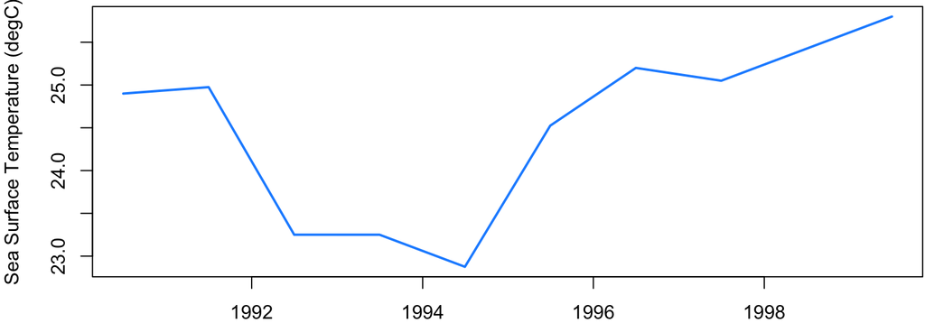

```r
sst = result(geoknife(data.frame(caspian.sea = c(51, 40)), fabric,
    wait = TRUE))
head(sst)
july.idx <- months(sst$DateTime) == "July"
plot(sst$DateTime[july.idx], sst$caspian.sea[july.idx], type = "l",
    lwd = 2, col = "dodgerblue", ylab = "Sea Surface Temperature (degC)",
    xlab = NA)
```

## geoknife in action

For our lake modeling activities, we use `geoknife` to create driver data for each lake we are modeling, and also to extract land-cover data from the NLCD that is in the buffer of each lake (for wind sheltering).

Alternatively, there are some examples in our [geoknife paper](http://onlinelibrary.wiley.com/doi/10.1111/ecog.01880/full) and our [geoknife blog post](http://www.ecography.org/blog/slicing-gridded-data-geoknife)

Looking at PRISM data for ecoregion:

[figure not shown]

## geoknife in action

For our lake modeling activities, we use `geoknife` to create driver data for each lake we are modeling, and also to extract land-cover data from the NLCD that is in the buffer of each lake (for wind sheltering).

Alternatively, there are some examples in our [geoknife paper](http://onlinelibrary.wiley.com/doi/10.1111/ecog.01880/full) and our [geoknife blog post](http://www.ecography.org/blog/slicing-gridded-data-geoknife)

And plotting time series data:

[figure not shown]

## geoknife for the script averse

[figure not shown]